# Guía Introduccion a los estudios de asociación genómica

### 4 - QTLs

Ahora exploraremos el efecto de los QTLs detectados por el GWAS

**a)** Explore el objeto **score** con el comando **head()** y **View()**.

```r
# View(scores)
head(score)
```

```
##   marker chrom pos          y
## 1   snp1     1   1 0.27068411
## 2   snp2     1   2 0.09321965
## 3   snp3     1   3 1.00621907
## 4   snp4     1   4 0.22399674
## 5   snp5     1   5 0.40095387
## 6   snp6     1   6 1.91710405
```

¿Qué SNP fueron significativos?  
**Sugerencia** Extraiga el score de los SNP significativos (score>5) usando la función **filter()** de la librería **dplyr*

```r
dplyr::filter(score, y > 5)
```

```
##    marker chrom pos        y
## 1  snp300     3 100 7.504724
## 2 snp1000    10 100 8.508100
```

```r
# snp300
exp(-7.5047236)
```

```
## [1] 0.000550478
```

```r
# pruebe calcular log(-0.000550478)

# snp1000
exp(-8.5080997)
```

```
## [1] 0.000201827
```

```r
# pruebe calcular log(-0.000201827)
```

**b)** Realice un gráfico de [regresión lineal](http://www.sthda.com/english/articles/40-regression-analysis/167-simple-linear-regression-in-r/) de fenotipo en función de los genotipo para cada SNP significativo.

Sugerencia: Transponga la matriz geno y cree un nuevo data.frame solo con los snp signiticativos, luego una al data.frame el rasgo cuantitativo.

```r
t_geno_300 <- t(geno[300,4:203])+1
t_geno_1000 <- t(geno[1000,4:203])+1
qtl <- data.frame(t_geno_300,t_geno_1000,pheno$y)

head(qtl)
```

```
##          X300 X1000    pheno.y
## animal_1    1     1 2.52813203
## animal_2    2     0 1.44348297
## animal_3    1     1 1.11555299
## animal_4    1     1 2.01623154
## animal_5    1     0 0.08267191
## animal_6    0     2 1.80765254
```

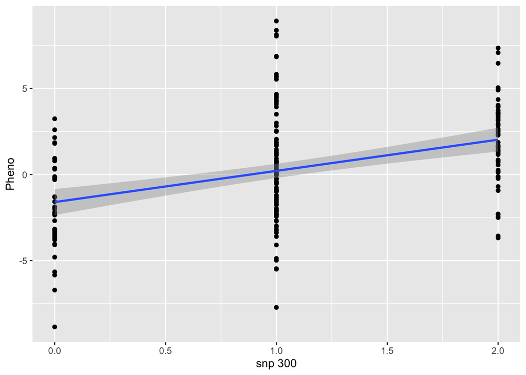

```r
qtl.1 <- ggplot(qtl, aes(x = X300, y = pheno.y))
qtl.1 + geom_point() + xlab("snp 300") +  ylab("Pheno")+ geom_smooth(method=lm)
```

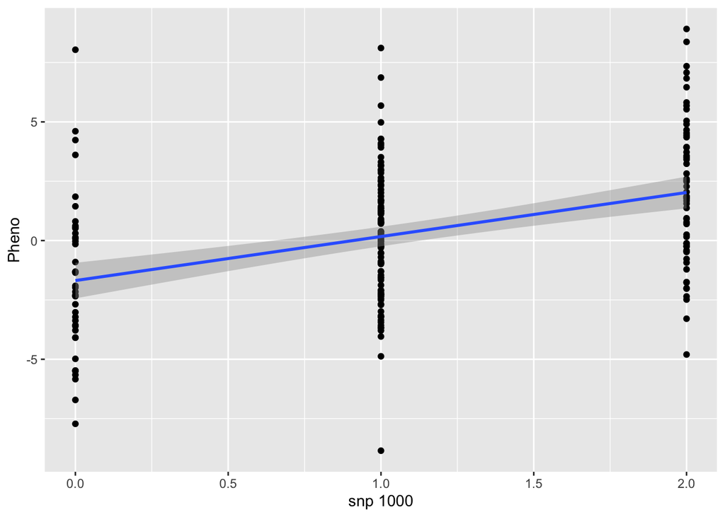

```r
qtl.2 <- ggplot(qtl, aes(x = X1000, y = pheno.y))
qtl.2 + geom_point() + xlab("snp 1000") +  ylab("Pheno")+ geom_smooth(method=lm)
```

**c)** Estime el efecto (beta o pendiente) de los QTLs con mayor score usando un modelo lineal **lm()**.

```r
lm.qtl.300 <- lm(pheno.y ~ X300, data = qtl)
summary(lm.qtl.300)
```

```
##
## Call:
## lm(formula = pheno.y ~ X300, data = qtl)
##
## Residuals:
##     Min      1Q  Median      3Q     Max
## -7.9292 -1.9076 -0.2454  1.5984  8.7040
##
## Coefficients:
##             Estimate Std. Error t value Pr(>|t|)
## (Intercept)  -1.6019     0.3831  -4.181 4.35e-05 ***
## X300          1.8121     0.3015   6.011 8.72e-09 ***
## ---
## Signif. codes:  0 '***' 0.001 '**' 0.01 '*' 0.05 '.' 0.1 ' ' 1
##
## Residual standard error: 2.956 on 198 degrees of freedom
## Multiple R-squared:  0.1543, Adjusted R-squared:  0.1501
## F-statistic: 36.13 on 1 and 198 DF,  p-value: 8.717e-09
```

```r
cat("El efecto del snp300 sobre el rasgo cuantitativo 1.8121")
```

```
## El efecto del snp300 sobre el rasgo cuantitativo 1.8121
```

```r
lm.qtl.1000 <- lm(pheno.y ~ X1000, data = qtl)
summary(lm.qtl.1000)
```

```
##
## Call:
## lm(formula = pheno.y ~ X1000, data = qtl)
##
## Residuals:
##     Min      1Q  Median      3Q     Max
## -9.0213 -2.2599 -0.1655  1.9001  9.7233
##
## Coefficients:
##             Estimate Std. Error t value Pr(>|t|)
## (Intercept)  -1.6845     0.3805  -4.428 1.57e-05 ***
## X1000         1.8549     0.2940   6.310 1.79e-09 ***
## ---
## Signif. codes:  0 '***' 0.001 '**' 0.01 '*' 0.05 '.' 0.1 ' ' 1
##
## Residual standard error: 2.933 on 198 degrees of freedom
## Multiple R-squared:  0.1674, Adjusted R-squared:  0.1632
## F-statistic: 39.81 on 1 and 198 DF,  p-value: 1.792e-09
```

```r
cat("El efecto del snp1000 sobre el rasgo cuantitativo 1.8549")
```

```
## El efecto del snp1000 sobre el rasgo cuantitativo 1.8549
```

### 7 - Referencias

**Jeffrey B. Endelman 2011.** Ridge Regression and Other Kernels for Genomic Selection with R Package rrBLUP. https://doi.org/10.3835/plantgenome2011.08.0024